# Trading and investment account summary

# For 2020-08-26

Summary text: The equity value of my live trading portfolio changed by 1.72 % (US$ 592.06 ) from US$ 34481.85 to US$ 35073.91 today ( 2020-08-26 ). The trading proceeds in my live account were US$ 1840.17 . The book proceeds in my portfolio changed from US$ 3281.21 to US$ 2033.1

## Portfolio

The below table shows the current positions in the live account as well as their current and total performance. “book_proceed” indicates the unrealized profit in that position.

| symbol | close | closePerc | Total_Change_close | entry_price | position | position_size | entry_position | totalPerc | book_proceed | sector |
| --- | --- | --- | --- | --- | --- | --- | --- | --- | --- | --- |
| KWEB | 71.14 | 0.51 | 36 | 69.95 | 100 | 7114.00 | 6995.43 | 1.67 | 118.57 | Miscellaneous |
| BRK.B | 214.67 | 0.62 | 33 | 195.40 | 25 | 5366.75 | 4885.08 | 8.98 | 481.67 | Finance |
| SEAS | 19.65 | -0.46 | 16.65 | 18.51 | -185 | -3635.25 | -3424.45 | -5.8 | -210.8 | Consumer Services |
| EZA | 38.52 | 0 | 0 | 38.54 | -75 | -2889.00 | -2890.50 | 0.05 | 1.5 | Miscellaneous |
| CAKE | 27.09 | -0.84 | -20.24 | 23.83 | 88 | 2383.92 | 2097.05 | 12.03 | 286.87 | Consumer Services |
| TSLA | 2151.93 | 6.32 | 127.84 | 1405.56 | 1 | 2151.93 | 1405.56 | 34.68 | 746.37 | Consumer Durables |
| SQ | 153.80 | -0.77 | -15.6 | 141.33 | 13 | 1999.40 | 1837.35 | 8.1 | 162.05 | Technology Services |
| INDA | 33.87 | 0.65 | 11 | 33.05 | 50 | 1693.50 | 1652.50 | 2.42 | 41 | Miscellaneous |
| GOOG | 1651.98 | 2.79 | 44.9 | 1599.21 | 1 | 1651.98 | 1599.21 | 3.19 | 52.77 | Technology Services |
| TPR | 14.84 | -0.67 | -8.5 | 14.96 | 85 | 1261.40 | 1271.99 | -0.84 | -10.59 | Retail Trade |
| SLV | 25.57 | 3.35 | 39.84 | 22.79 | 48 | 1227.36 | 1093.73 | 10.89 | 133.63 | Miscellaneous |
| MIK | 11.09 | 6.02 | 63 | 8.51 | 100 | 1109.00 | 851.26 | 23.24 | 257.74 | Retail Trade |
| UNM | 18.37 | -1.55 | -14.5 | 19.21 | 50 | 918.50 | 960.30 | -4.55 | -41.8 | Finance |
| RVLV | 20.07 | -2.29 | -17.86 | 18.07 | 38 | 762.66 | 686.53 | 9.98 | 76.13 | Retail Trade |
| GOLD | 29.37 | 2.19 | 15.75 | 28.06 | 25 | 734.25 | 701.56 | 4.45 | 32.69 | Non-Energy Minerals |
| SWKS | 142.69 | 0.06 | 0.45 | 131.85 | 5 | 713.45 | 659.25 | 7.6 | 54.2 | Electronic Technology |
| CAT | 141.83 | 0.51 | 3.6 | 142.04 | 5 | 709.15 | 710.20 | -0.15 | -1.05 | Producer Manufacturing |
| IAU | 18.64 | 1.25 | 8.74 | 19.00 | 38 | 708.32 | 722.00 | -1.93 | -13.68 | Miscellaneous |
| PPLT | 88.25 | 0.59 | 4.16 | 89.44 | 8 | 706.00 | 715.49 | -1.34 | -9.49 | Miscellaneous |
| EPHE | 26.90 | -0.11 | 0.75 | 25.67 | -25 | -672.50 | -641.70 | -4.58 | -30.8 | Miscellaneous |
| V | 210.27 | 1.03 | 6.45 | 194.66 | 3 | 630.81 | 583.99 | 7.42 | 46.82 | Finance |
| PALL | 206.62 | 1.55 | 9.45 | 219.68 | 3 | 619.86 | 659.04 | -6.32 | -39.18 | Miscellaneous |
| DBX | 20.58 | 2.18 | 13.2 | 20.73 | 30 | 617.40 | 621.75 | -0.7 | -4.35 | Technology Services |
| MGM | 22.00 | -0.41 | -2.25 | 21.35 | 25 | 550.00 | 533.75 | 2.95 | 16.25 | Consumer Services |
| NFLX | 547.37 | 11.58 | 56.79 | 486.00 | 1 | 547.37 | 486.00 | 11.21 | 61.37 | Consumer Services |
| UPWK | 14.66 | 1.1 | 5.76 | 14.48 | 36 | 527.76 | 521.36 | 1.21 | 6.4 | Technology Services |
| LMND | 61.13 | 0.15 | 0.72 | 78.07 | 8 | 489.04 | 624.57 | -27.71 | -135.53 | Finance |
| CCL | 15.29 | -3.84 | -15.25 | 14.54 | 25 | 382.25 | 363.50 | 4.91 | 18.75 | Consumer Services |
| ILMN | 353.56 | 0.76 | 2.65 | 346.12 | 1 | 353.56 | 346.12 | 2.1 | 7.44 | Health Technology |
| GDX | 41.57 | 2.44 | 7.92 | 43.89 | 8 | 332.56 | 351.14 | -5.59 | -18.58 | Miscellaneous |
| CRUS | 60.95 | 0.84 | 2.55 | 71.60 | 5 | 304.75 | 358.02 | -17.48 | -53.27 | Electronic Technology |

| symbol | close | closePerc | Total_Change_close | entry_price | position | position_size | entry_position | totalPerc | book_proceed | sector |
| --- | --- | --- | --- | --- | --- | --- | --- | --- | --- | --- |
| Summary | NA | NA | 416.97 | NA | 1110 | 43763.68 | NA | 4.65 | 2033.103 | NA |

[interactive chart not shown]

The performance of my live stock portfolio/trading account vs. my paper trading account and the benchmark ‘SPY’, the US large cap stock market index ETF in percent since June 09 2020.

[interactive chart not shown]

This plot shows a summary of the trading activity on that day. Above 0 is a gain, below is a loss. TRUE indicated live trading account, FALSE is paper trading. A buy side trade is a closed short sale trade and sell side trade is a closed long trade.

[interactive chart not shown]

My current portfolio sorted by sectors. The plot reads clock-wise. Positions below 0 are short positions. Clicking a slice of the pie chart directs to marketwatch.com for further information.

[interactive chart not shown]

These two plots indicate the composition of my portfolio and the change of it over the past week.

[interactive chart not shown]

The inner circle is Monday, the outer circle is Friday.

[interactive chart not shown]

The colors in this plot indicate the daily percentage change of each stock in my portfolio.

[interactive chart not shown]

I classified the stocks in my portfolio by sector. The area represents the size of the position in the portfolio. Long postions

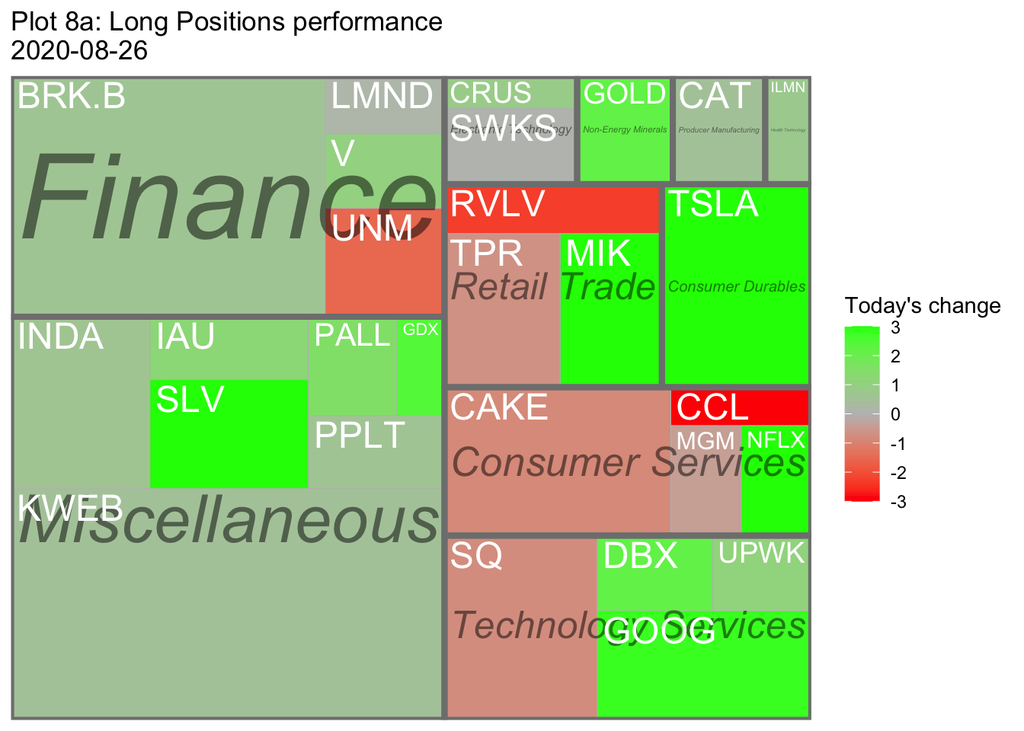

Short postions

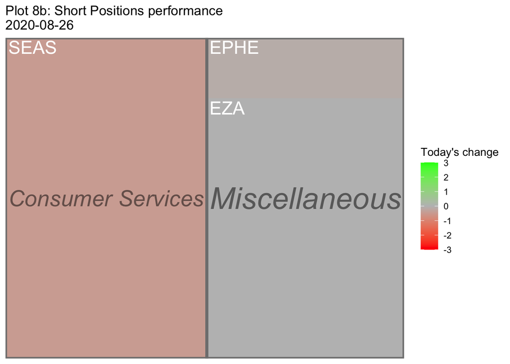

S&P 500 stocks colored by last day performance.

Outliers skew the colors, making the other stocks look pale. I restricted the colors to max of 3 and -3% change. Every stock having higher or lower than 3% change has the same color.

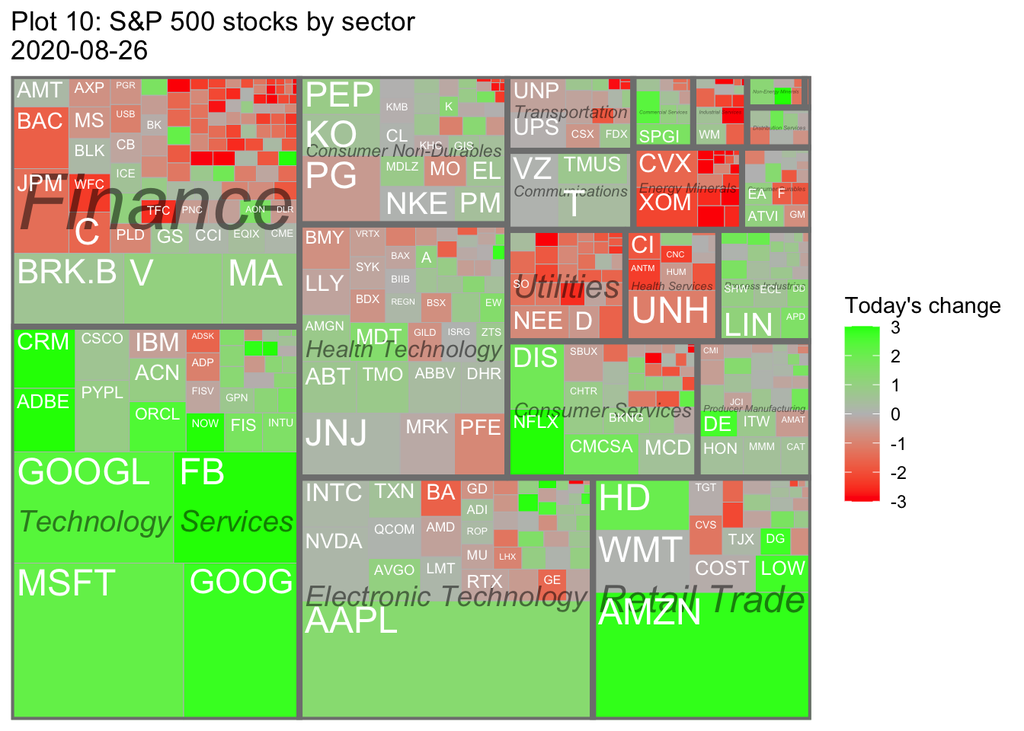

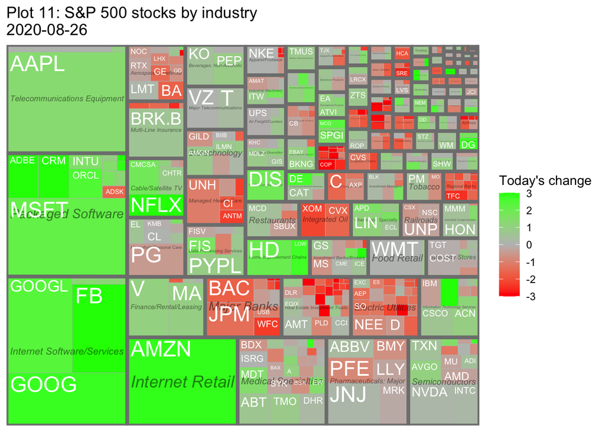